# Chapter 2, Problem 2.7

James Topor

February 8, 2016

# ——————————————————————-

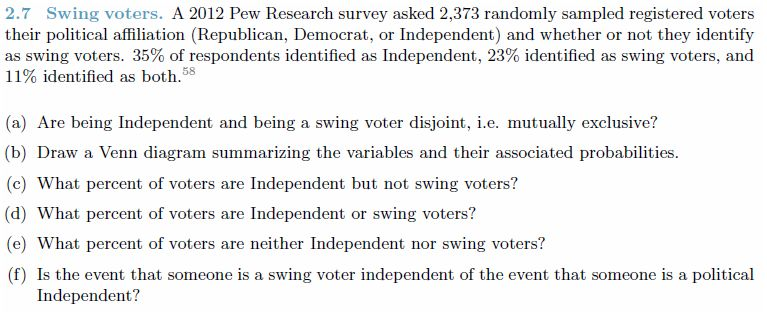

# ——————————————————————-

**a) Are being Independent and being a swing voter disjoint, i.e. mutually exclusive?**

No they are not disjoint since 11% of voters identify as both independent and swing voters.

**b) Draw a Venn diagram summarizing the variables and their associated probabilities.**

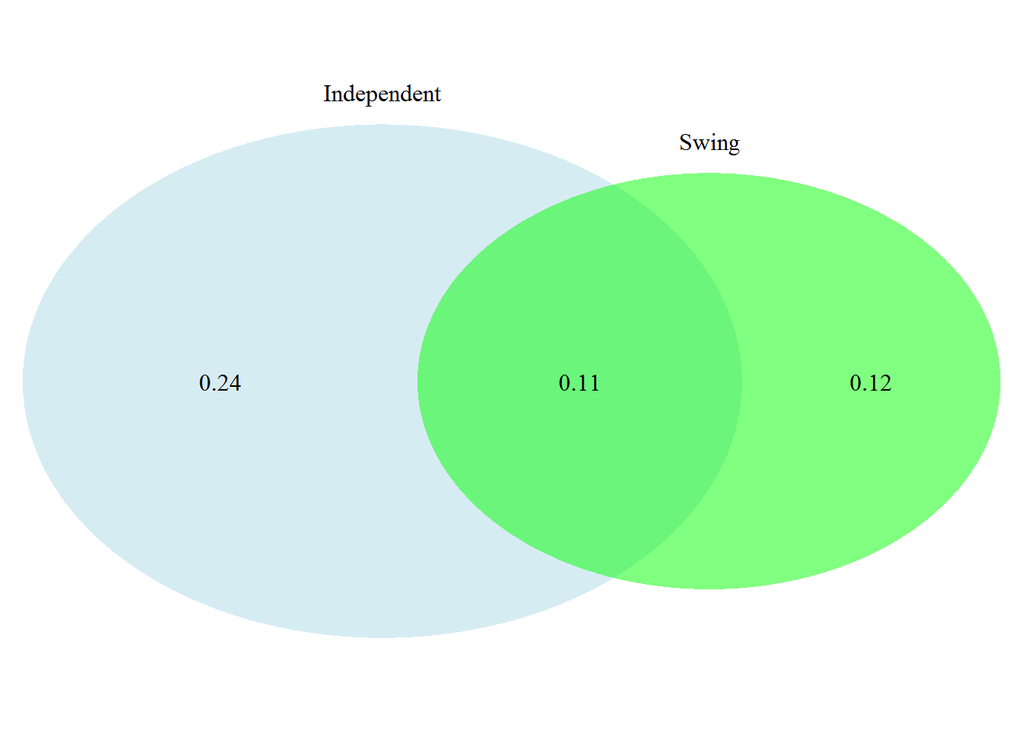

[output not shown]

**c) What percent of voters are Independent but not swing voters?**

We are told that 35% of voters are independent, and 11% of voters identify as both independent AND swing voters. Therefore, the percentage of voters that are independent but not swing voters is:

$.35 - .11 = .24 = 24$%

**d) What percent of voters are Independent or swing voters?**

We are told that 35% of voters are Independent, 23% are swing voters, and 11% identify as both Independent AND swing. Therefore, the percentage of voters that are Independent OR swing voters is:

$.35 + .23 - .11 = .47 = 47$%

**e) What percent of voters are neither Independent nor swing voters?**

The percentage of voters that are neither independent nor swing voters is the **complement** of the percentage of voters that are EITHER independent or swing, which we calculated in our answer to part **d)** above as 47%. Therefore, we can simply subtract .47 from 1 to find our answer:

$1 - .47 = .53 = 53$%

**f) Is the event that someone is a swing voter independent of the event that someone is a political Independent?**

No since there is overlap between the two groups. As we’re told, 11% of voters identify as both independent and swing.

We can also show this mathematically by testing for equivalence of $P(A) * P(B) = P(A,B)$ where P(A) is the probability of being independent and P(B) is the probability of being a swing voter:

- P(Independent) = .35 = P(A)
- P(Swing) = .23 = P(B)
- P(A) * P(B) = .35 * .23 = 0.0805
- P(A,B) = .11 (given to us in text)

As we can see, $(P(A) * P(B) = .0805) != (P(A,B) = .11)$ so these events are NOT independent.